# Exposure to Social Media Ads

## Introduction

In a world where technology runs the world, advertising has shifted towards different social media platforms. We are constantly exposed to ads wherever we go, which raises questions about user experience, ad targeting and content saturation. Using self-logged data over several days by multiple participants we explored patterns in social media media exposure. The aim is to identify behaviours, types and frequency of ads using the data we have gathered.

The analysis focuses on: - Distribution of ad types across product categories - Temporal trends in ad volume - Repetition and exposure dynamics, particularly for video ads

- Distribution of ads across product/service categories based on their format
- Repetition of ads on different platforms, particularly for video ads
- Trend in ad volume over time

## Dataset Overview

The data was logged using Google Forms and is then imported from a Google Sheet. Includes variable such as:

- **Timestamp**: When the ad was seen
- **Platform**: Social media platform (e.g., Instagram, TikTok)
- **Product Type**: What the ad was promoting (e.g., fashion, gaming)
- **Ad Format**: How the ad was presented (e.g., image, video)
- **Ad Exposure**: Number of ads seen in the last 10 minutes
- **Repetition Metrics**: Number of times the same ad was seen that day

Renaming variables and data parsing were performed to make it easier to work with the data. For comparative analysis, ad types were grouped into “Video Ad” and “Non-Video Ad”.

## Which types of products are dominating my ad feed?

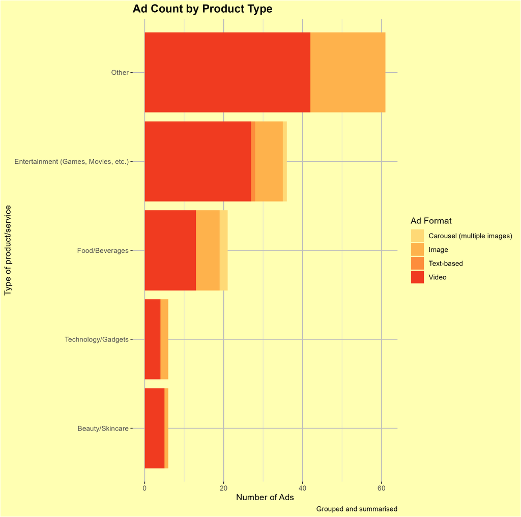

This chart highlights which product categories dominate ad space. Certain industries (such as gaming or food) have significantly higher ad counts, which suggest either increased targeting efforts or high algorithm placement.

Notably:

- The top three product types account for more than half of all recorded ads.
- Ads that don’t fall within these category fall in the ‘Other’ category.

This visualisation helps illustrate **where advertising resources are being concentrated**. With ‘Other’ being the top category wasn’t much of a surprise as it would’ve been anything for what we know.

## Are there certain days when I see way more ads?

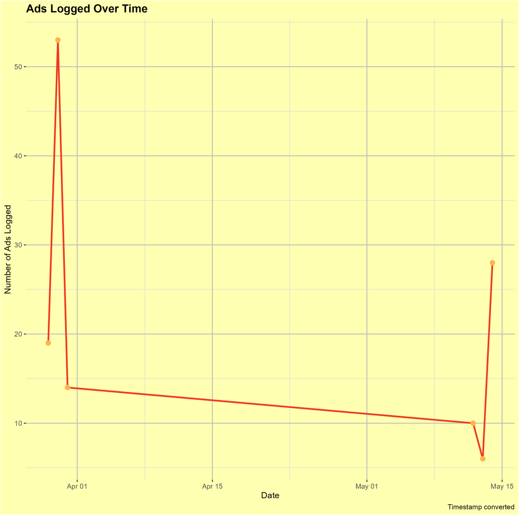

This line chart tracks the number of ads over the span of several days. The peaks and valleys reflects on user activity, platform ad frequency or specific days with certain goal.

This plot reveals the **amount of exposure** we have on ads on a day-to-day basis.

## Am I seeing the same ads over and over again?

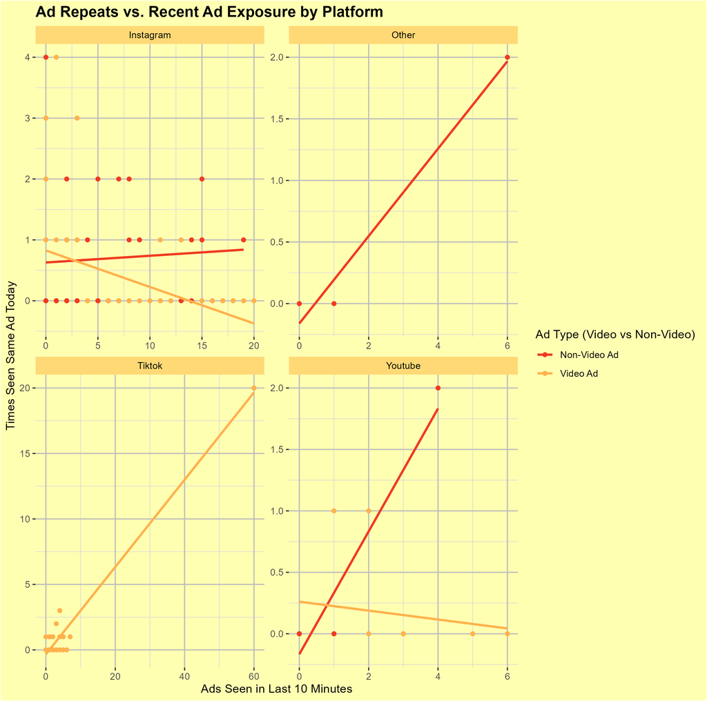

Scatter plot showing number of ads seen in last 10 minutes and number of time it was seen that day grouped by either a video or non-video

This scatter plot explores the relationship between **short-term exposure** (ads seen in the last 10 minutes) and **daily repetition** (how many times the same ad appeared).

This visualization supports the idea that **platforms differ in their ad delivery algorithms**, especially when comparing video and static formats.

## Insights and Interpretation

From the visuals and data patterns, we can draw several insights:

1. **Ad Type Dominance**: Certain product categories dominate digital ad space. Brands in these categories may have larger budgets or more aggressive campaign strategies.
2. **Time-Based Trends**: Ad exposure isn’t random. It’s shaped by both platform use patterns and strategic scheduling by advertisers.
3. **Platform Behaviour**: Video ads are treated differently across platforms, possibly due to their higher engagement rates or higher cost per impression.

## Reflections and Limitations

While the dataset provides useful insights, there are some limitations:

- The sample size is based on a very few amount of logger, meaning we can’t say that the results are generalisable.
- One log entry was an outlier as they didn’t quite understood the procedure meaning they entered the amount of ads they have seen in the past 10 mins and the sum of times they saw the same ad that day.
- Ad logging might miss short-lived or skipped content.

In the future more participants would be better and perhaps could also involve features such as automated ad detection.

## Conclusion

This data story uncovers meaningful patterns in digital ad exposure. We learned that product type, platform, and format play key roles in how users experience advertising. Understanding these can help advertisers create smarter, less intrusive campaigns — and help users become more aware of how they are being targeted.

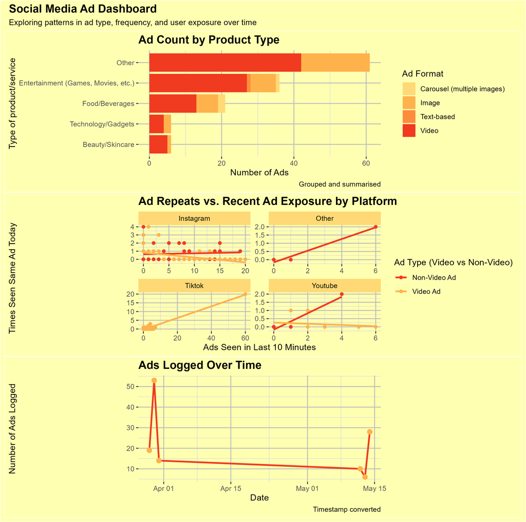

By leveraging simple tracking and visual analytics, we gain valuable perspective into one of the most pervasive elements of modern digital life.